# Lab 8: ANCOVA and interactions

Author

Yinjiao Zhong

Published

April 3, 2024

## 0.1 Lab Setup

```r
library(car)
# Set working directory
setwd("~/Desktop/EAS 538 Lab")
# Read in data
dataset <- read.csv(file = "sanddata.csv", sep = ",", header = T,comment.char = "#")
head(dataset, 3)
```

```
  juveniles     sand temperature  rainfall humanpop country
1  1450.489 348.7163    27.84830  907.7776 666.8436   China
2  1306.366 766.6340    27.02602 1280.4317 780.5680   China
3  1900.798 431.7617    24.70595 1430.2775 441.4950   China
```

# 1 Exercise 1

```r
cor(dataset[,-6],dataset[,-6])
```

```
              juveniles        sand  temperature    rainfall     humanpop
juveniles    1.00000000 -0.40060237 -0.287562662  0.13030061 -0.093874549
sand        -0.40060237  1.00000000  0.278387847 -0.10758403  0.040841125
temperature -0.28756266  0.27838785  1.000000000 -0.40000000  0.008017561
rainfall     0.13030061 -0.10758403 -0.400000000  1.00000000  0.022808524
humanpop    -0.09387455  0.04084112  0.008017561  0.02280852  1.000000000
```

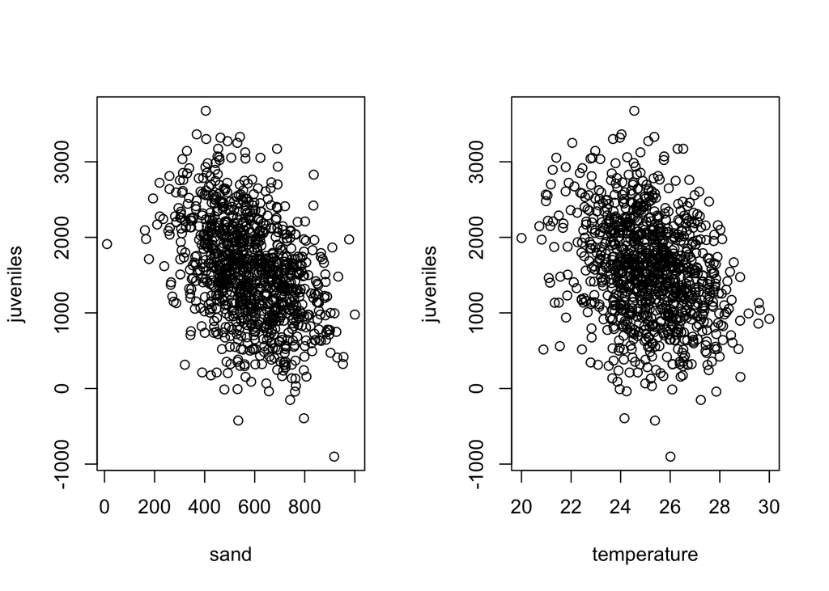

```r
linmod <- lm(juveniles ~ sand + temperature + rainfall + humanpop + country, data = dataset)
par(mfrow = c(1,2))
plot(juveniles ~ sand, data = dataset)
plot(juveniles ~ temperature, data = dataset)
```

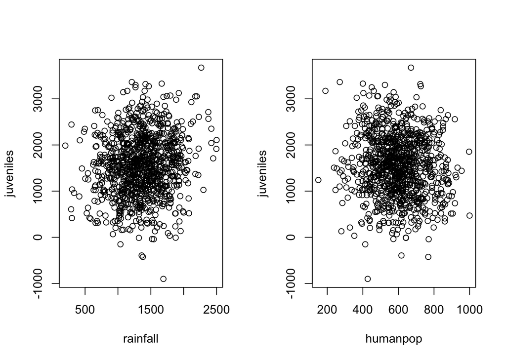

```r
plot(juveniles ~ rainfall, data = dataset)
plot(juveniles ~ humanpop, data = dataset)
```

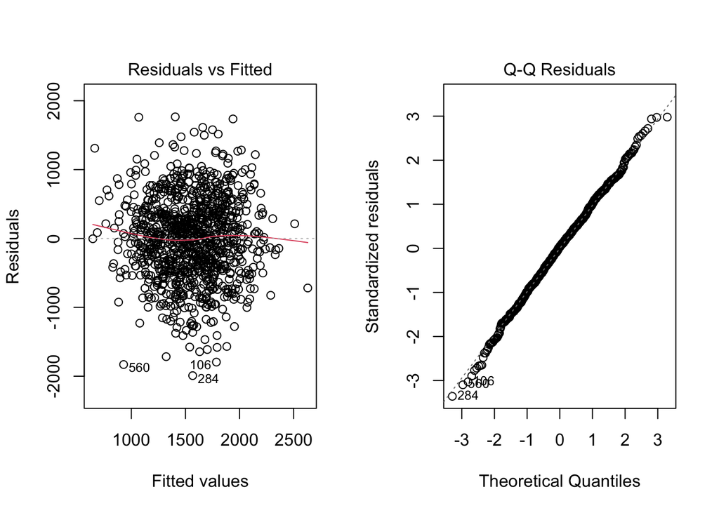

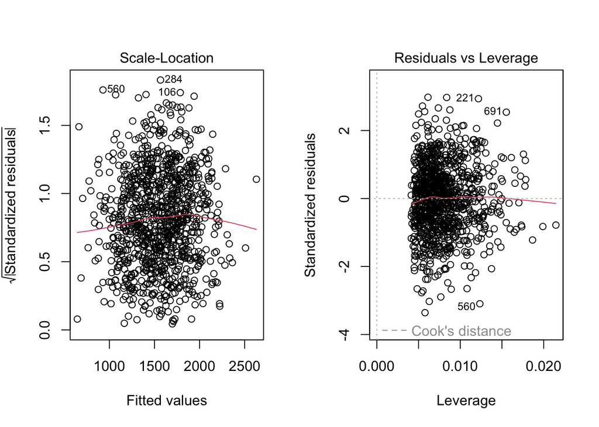

```r
par(mfrow = c(1,2))
plot(linmod)
```

```r
summary(linmod)
```

```
Call:
lm(formula = juveniles ~ sand + temperature + rainfall + humanpop +
    country, data = dataset)

Residuals:
     Min       1Q   Median       3Q      Max
-1991.38  -393.25    21.99   389.21  1766.18

Coefficients:
                   Estimate Std. Error t value Pr(>|t|)
(Intercept)      4603.65570  374.53180  12.292  < 2e-16 ***
sand               -1.51796    0.13221 -11.481  < 2e-16 ***
temperature       -76.81031   13.51391  -5.684 1.73e-08 ***
rainfall            0.04423    0.05576   0.793 0.427860
humanpop           -0.39505    0.14076  -2.807 0.005104 **
countryIndia      -33.74344   53.20575  -0.634 0.526092
countryIndonesia  -46.85508   53.30556  -0.879 0.379619
countryMalaysia  -190.48339   53.30196  -3.574 0.000369 ***
---
Signif. codes:  0 '***' 0.001 '**' 0.01 '*' 0.05 '.' 0.1 ' ' 1

Residual standard error: 594.7 on 992 degrees of freedom
Multiple R-squared:  0.2125,    Adjusted R-squared:  0.2069
F-statistic: 38.24 on 7 and 992 DF,  p-value: < 2.2e-16
```

## 1.1 Question 1.1

**Answer**:

- As the result, we can know there is no multicollinearity between these variables from cor table.
- Because P-value of intercept is 2e-16 << alpha = 0.05, we can reject null hypothesis. While all independent variables were 0, baseline country of China has juveniles crane signicantly not 0, and the expected value is 4603.65570.
- For the `temperature` variable, the P-value is 1.73e-08 << alpha = 0.05, we can reject null hypothesis, there is a significant relationship between `temperature` and `juveniles`, this means for each additional unit of `temperature`, the number of juvenile cranes decreased by 76.81.
- For the `humanpop` variable, the P-value is 0.005104 < alpha = 0.05, we can reject null hypothesis, there is a significant relationship between `humanpop` and `juveniles`, this means for each additional unit of `humanpop`, the number of juvenile cranes decreased by 0.39505.
- For the `countryMalaysia` variable, the P-value is 0.000369 < alpha = 0.05, we can reject null hypothesis, there is a significant relationship between `countryMalaysia` and `juveniles`, this means for each additional unit of `countryMalaysia`, the number of juvenile cranes decreased by 190.48339 compared to baseline country China.
- Because the multiple R-squared is 0.2125, this means this model could explain 21.25% of the variation in the number of juvenile cranes.

## 1.2 Question 1.2

**Answer**:

- For the `rainfall` variable, the P-value is 0.427860 > alpha = 0.05, we can not to reject null hypothesis, this means there was no significant correlation between `rainfall` and the number of juvenile cranes.
- For the `countryIndia` variable, the P-value is 0.526092 > alpha = 0.05, we can not to reject null hypothesis, this means there was no significant correlation between `countryIndia` and the number of juvenile cranes.
- For the `countryIndonesia` variable, the P-value is 0.379619 > alpha = 0.05, we can not to reject null hypothesis, this means there was no significant correlation between `countryIndonesia` and the number of juvenile cranes, while all independent variables held constant.

# 2 Exercise 2

## 2.1 Question 2.1

```r
table(dataset$country)
```

```
    China     India Indonesia  Malaysia
      250       250       250       250
```

```r
dataset$country <- as.factor(dataset$country)
dataset$country <- relevel(dataset$country, ref = 'India')
linmod2 <- lm(juveniles ~ sand + temperature + rainfall + humanpop + country, data = dataset)
summary(linmod2)
```

```
Call:
lm(formula = juveniles ~ sand + temperature + rainfall + humanpop +
    country, data = dataset)

Residuals:
     Min       1Q   Median       3Q      Max
-1991.38  -393.25    21.99   389.21  1766.18

Coefficients:
                   Estimate Std. Error t value Pr(>|t|)
(Intercept)      4569.91226  374.62321  12.199  < 2e-16 ***
sand               -1.51796    0.13221 -11.481  < 2e-16 ***
temperature       -76.81031   13.51391  -5.684 1.73e-08 ***
rainfall            0.04423    0.05576   0.793  0.42786
humanpop           -0.39505    0.14076  -2.807  0.00510 **
countryChina       33.74344   53.20575   0.634  0.52609
countryIndonesia  -13.11165   53.26062  -0.246  0.80559
countryMalaysia  -156.73996   53.27943  -2.942  0.00334 **
---
Signif. codes:  0 '***' 0.001 '**' 0.01 '*' 0.05 '.' 0.1 ' ' 1

Residual standard error: 594.7 on 992 degrees of freedom
Multiple R-squared:  0.2125,    Adjusted R-squared:  0.2069
F-statistic: 38.24 on 7 and 992 DF,  p-value: < 2.2e-16
```

**Answer**:

Comparing the results of the two models, the four variable coefficients of `sand`, `temperature`, `rainfall` and `humanpop` did not change. In the original model, the coefficient for India is -33.74344, while in the new model, the coefficient for China was 33.74344. The coefficients for Indonesia from -46.85508 to -13.11165, and Malaysia from -190.48339 to -156.73996 are changed. This is because in the new model, India is specified as the intercept, so the coefficients for other countries are reestimated relative to the effect for India.

## 2.2 Question 2.2

```r
anomod <- aov(juveniles ~ sand + temperature + rainfall + humanpop + country, data = dataset)
leveneTest(juveniles ~ country, data = dataset)
```

```
Levene's Test for Homogeneity of Variance (center = median)
       Df F value Pr(>F)
group   3  0.2372 0.8704
      996
```

```r
summary(anomod)
```

```
             Df    Sum Sq  Mean Sq F value   Pr(>F)
sand          1  71493399 71493399 202.153  < 2e-16 ***
temperature   1  14965606 14965606  42.316 1.23e-10 ***
rainfall      1    145897   145897   0.413  0.52083
humanpop      1   2763535  2763535   7.814  0.00528 **
country       3   5291448  1763816   4.987  0.00194 **
Residuals   992 350831089   353660
---
Signif. codes:  0 '***' 0.001 '**' 0.01 '*' 0.05 '.' 0.1 ' ' 1
```

```r
TukeyHSD(anomod)
```

```
  Tukey multiple comparisons of means
    95% family-wise confidence level

Fit: aov(formula = juveniles ~ sand + temperature + rainfall + humanpop + country, data = dataset)

$country
                         diff       lwr        upr     p adj
China-India          33.65691 -103.2243 170.538169 0.9214750
Indonesia-India     -12.48032 -149.3616 124.400940 0.9954520
Malaysia-India     -156.02170 -292.9030 -19.140443 0.0180125
Indonesia-China     -46.13723 -183.0185  90.744030 0.8217020
Malaysia-China     -189.67861 -326.5599 -52.797353 0.0021473
Malaysia-Indonesia -143.54138 -280.4226  -6.660123 0.0356149
```

**Answer**:

From the `TukeyHSD` test, we can reject the null hypothesis that `Malaysia-China`, `Malaysia-India`, `Malaysia-Indonesia` are significantly different from one another, because their P-value < alpha = 0.05. For the `TukeyHSD` test, we know how the number of juvenile cranes varies from different countries, and which countries have significant differences. This information is not directly available when running a linear model `linmod`, which only provides coefficients for each country and does not provide a direct comparison between them. The `TukeyHSD` test provides us with accurate estimates and confidence intervals of mean differences between variables, taking into account multiple comparisons.

## 2.3 Question 2.3

```r
anomod3 <- aov(juveniles ~ temperature + rainfall + humanpop + country + sand,data = dataset)
summary(anomod3)
```

```
             Df    Sum Sq  Mean Sq F value   Pr(>F)
temperature   1  36838666 36838666 104.164  < 2e-16 ***
rainfall      1    123752   123752   0.350 0.554294
humanpop      1   3777373  3777373  10.681 0.001120 **
country       3   7298916  2432972   6.879 0.000138 ***
sand          1  46621178 46621178 131.825  < 2e-16 ***
Residuals   992 350831089   353660
---
Signif. codes:  0 '***' 0.001 '**' 0.01 '*' 0.05 '.' 0.1 ' ' 1
```

```r
summary(anomod)
```

```
             Df    Sum Sq  Mean Sq F value   Pr(>F)
sand          1  71493399 71493399 202.153  < 2e-16 ***
temperature   1  14965606 14965606  42.316 1.23e-10 ***
rainfall      1    145897   145897   0.413  0.52083
humanpop      1   2763535  2763535   7.814  0.00528 **
country       3   5291448  1763816   4.987  0.00194 **
Residuals   992 350831089   353660
---
Signif. codes:  0 '***' 0.001 '**' 0.01 '*' 0.05 '.' 0.1 ' ' 1
```

**Answer**:

- They have same variables significant such as `sand`, `temperature`, `humanpop` and `country`, but `rainfall` is no significant because p-value > alpha = 0.05.
- The difference in p-values for variables expect sand between `anomod` and `anomod3` occurs due to the sequential nature of how an `ANOVA` works, which is different from how it’s done in a linear regression model.
- Variables that enter the sequence earlier in `anomod3` show a smaller p-value compared to `anomod` because they account for more of the variation. In contrast, variables entered later have larger p-values because they explain less variation.

# 3 Exercise 3

## 3.1 Question 3.1

```r
# get interaction term between humanpop and country
dataset$country <- relevel(dataset$country, ref = 'China')
linmod5 <- lm(juveniles ~ sand + temperature + rainfall + humanpop +
    country + humanpop*country, data = dataset)
summary(linmod5)
```

```
Call:
lm(formula = juveniles ~ sand + temperature + rainfall + humanpop +
    country + humanpop * country, data = dataset)

Residuals:
     Min       1Q   Median       3Q      Max
-2069.41  -377.15    22.72   372.91  1815.50

Coefficients:
                            Estimate Std. Error t value Pr(>|t|)
(Intercept)               5054.11977  393.38223  12.848  < 2e-16 ***
sand                        -1.46417    0.13253 -11.048  < 2e-16 ***
temperature                -75.31818   13.45138  -5.599 2.79e-08 ***
rainfall                     0.03631    0.05553   0.654 0.513325
humanpop                    -1.24563    0.28476  -4.374 1.35e-05 ***
countryIndia              -818.65030  257.22667  -3.183 0.001505 **
countryIndonesia          -961.39246  263.20231  -3.653 0.000273 ***
countryMalaysia           -676.65413  226.87548  -2.982 0.002929 **
humanpop:countryIndia        1.31526    0.42169   3.119 0.001867 **
humanpop:countryIndonesia    1.53082    0.43181   3.545 0.000411 ***
humanpop:countryMalaysia     0.81239    0.36897   2.202 0.027909 *
---
Signif. codes:  0 '***' 0.001 '**' 0.01 '*' 0.05 '.' 0.1 ' ' 1

Residual standard error: 591 on 989 degrees of freedom
Multiple R-squared:  0.2247,    Adjusted R-squared:  0.2169
F-statistic: 28.66 on 10 and 989 DF,  p-value: < 2.2e-16
```

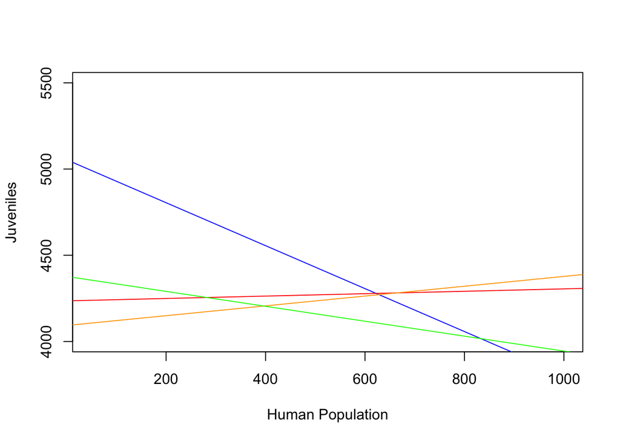

```r
plot(1:1000, rep(-100, 1000), ylim = c(4000, 5500), xlim = c(50, 1000), xlab = 'Human Population', ylab = 'Juveniles')
# China
abline(a = 5054.11977, b = -1.24563, col = 'blue')
# India
abline(a = 5054.11977 - 818.65030, b = -1.24563 + 1.31526, col = 'red')
# Indonesia
abline(a = 5054.11977 - 961.39246 , b = -1.24563 + 1.53082, col = 'orange')
# Malaysia
abline(a = 5054.11977 - 676.65413, b = -1.24563 + 0.81239, col = 'green')
```

**Answer**:

# 4 Extra Credit (Code and outputs required)

```r
# get the data
data("iris")
head(iris,3)
```

```
  Sepal.Length Sepal.Width Petal.Length Petal.Width Species
1          5.1         3.5          1.4         0.2  setosa
2          4.9         3.0          1.4         0.2  setosa
3          4.7         3.2          1.3         0.2  setosa
```

```r
# get multicollinearity
cor(iris[, c("Sepal.Length", "Sepal.Width", "Petal.Length", "Petal.Width")])
```

```
             Sepal.Length Sepal.Width Petal.Length Petal.Width
Sepal.Length    1.0000000  -0.1175698    0.8717538   0.8179411
Sepal.Width    -0.1175698   1.0000000   -0.4284401  -0.3661259
Petal.Length    0.8717538  -0.4284401    1.0000000   0.9628654
Petal.Width     0.8179411  -0.3661259    0.9628654   1.0000000
```

```r
# run linear regression model
linmod6 <- lm(Sepal.Length ~ Sepal.Width + Petal.Length + Petal.Width + Species, data = iris)
summary(linmod6)
```

```
Call:
lm(formula = Sepal.Length ~ Sepal.Width + Petal.Length + Petal.Width +
    Species, data = iris)

Residuals:
     Min       1Q   Median       3Q      Max
-0.79424 -0.21874  0.00899  0.20255  0.73103

Coefficients:
                  Estimate Std. Error t value Pr(>|t|)
(Intercept)        2.17127    0.27979   7.760 1.43e-12 ***
Sepal.Width        0.49589    0.08607   5.761 4.87e-08 ***
Petal.Length       0.82924    0.06853  12.101  < 2e-16 ***
Petal.Width       -0.31516    0.15120  -2.084  0.03889 *
Speciesversicolor -0.72356    0.24017  -3.013  0.00306 **
Speciesvirginica  -1.02350    0.33373  -3.067  0.00258 **
---
Signif. codes:  0 '***' 0.001 '**' 0.01 '*' 0.05 '.' 0.1 ' ' 1

Residual standard error: 0.3068 on 144 degrees of freedom
Multiple R-squared:  0.8673,    Adjusted R-squared:  0.8627
F-statistic: 188.3 on 5 and 144 DF,  p-value: < 2.2e-16
```

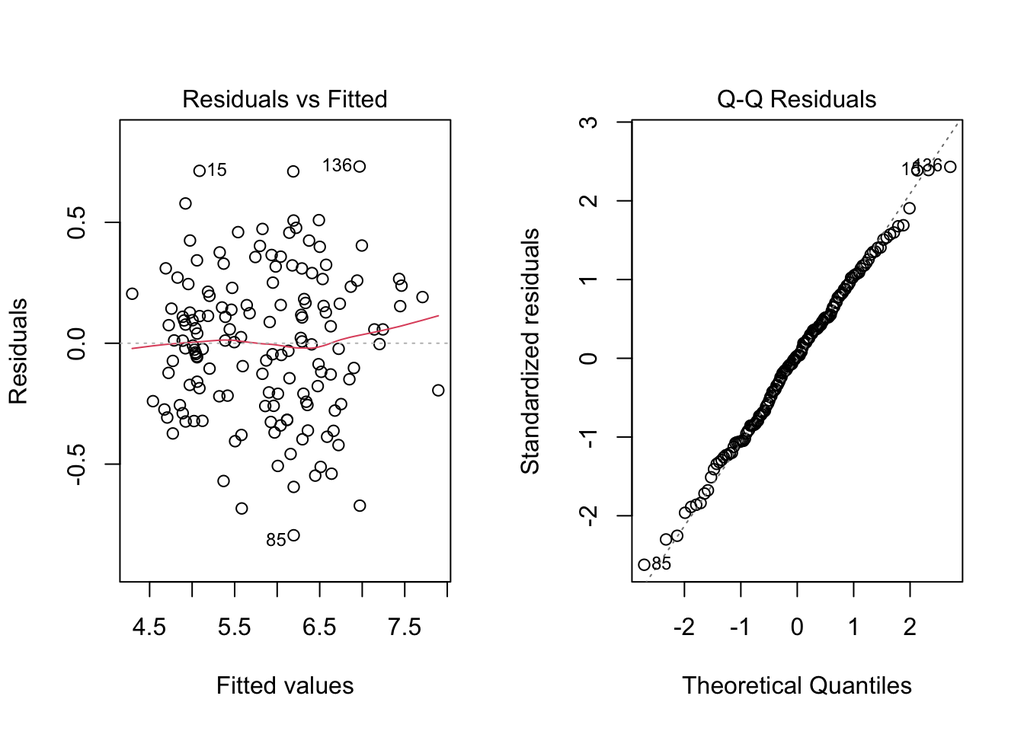

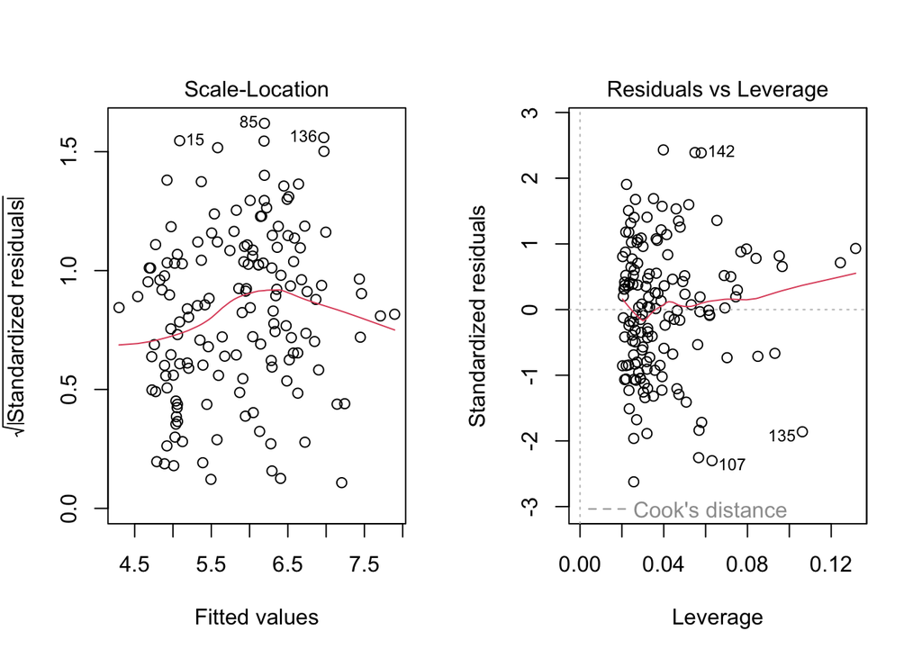

```r
# check assumptions of linmod6
par(mfrow = c(1, 2))
plot(linmod6)
```

```r
summary(aov(Sepal.Length ~ Sepal.Width + Petal.Length + Petal.Width + Species, data = iris))
```

```
              Df Sum Sq Mean Sq F value   Pr(>F)
Sepal.Width    1   1.41    1.41  15.001 0.000163 ***
Petal.Length   1  84.43   84.43 896.806  < 2e-16 ***
Petal.Width    1   1.88    1.88  20.005 1.56e-05 ***
Species        2   0.89    0.44   4.721 0.010329 *
Residuals    144  13.56    0.09
---
Signif. codes:  0 '***' 0.001 '**' 0.01 '*' 0.05 '.' 0.1 ' ' 1
```

**Answer**:

- From the aov result, we could know that `Sepal.Width`, `Petal.Length`, `Petal.Width` and `Species` have significant influences on `Sepal.Length`, because their P-values are all less than alpha = 0.05.
- We also get `Petal.Length` has the most significant influence on `Sepal.Length` from linear regression model, because its coefficient is 0.82924, which means increase of `Petal.Length` per unit, `Sepal.Length` will increase by 0.82924 units.
- From the correlation coefficient matrix, we could know `Sepal.Length` has a high positive correlation with `Petal.Length` and `Petal.Width`, but a weak negative correlation with `Sepal.Width`.